# Cyclistic Case Study - Report

Rohith Vimal

2024-05-07

## Scenario

‘*You are a junior data analyst working on the marketing analyst team at Cyclistic, a bike-share company in Chicago. The director of marketing believes the company’s future success depends on maximizing the number of annual memberships. Therefore, your team wants to understand how casual riders and annual members use Cyclistic bikes differently. From these insights, your team will design a new marketing strategy to convert casual riders into annual members. But first, Cyclistic executives must approve your recommendations, so they must be backed up with compelling data insights and professional data visualizations.*’

From this, the business goal as I infer it is:

‘**Design a marketing strategy, evidenced by the data, to convert Cyclistic’s casual riders into annual members.**’

As an analyst on this project, it is my responsibility to organise and gather insights from the data to support the creation of this marketing strategy.

## Understanding the Problem

The marketing team outlines the following 3 questions to guide their effort toward the aforementioned business goal:

1. How do annual members and casual riders use Cyclistic bikes differently?
2. Why would casual riders buy Cyclistic annual memberships?
3. How can Cyclistic use digital media to influence casual riders to become members?

The case study mentions that my manager and the Director of Marketing, Lily Moreno, has assigned me to specifically answer the first of the 3 questions. To bring clarity to the task at hand, I reformulated it following the SMART question approach:

‘**How have Cyclistic’s casual and annual-membership users differed in their use of the service over the previous year?**’

My deliverable for this assignment is a report containing the following information:

1. A clear statement of the business task
2. A description of all data sources used
3. Documentation of any cleaning or manipulation of data
4. A summary of your analysis
5. Supporting visualizations and key findings
6. Your top three recommendations based on your analysis

These points will be addressed over the course of this report.

## Scope of Work (SoW)

#### Business Task:

‘**How have Cyclistic’s casual and annual-membership users differed in their use of the service over the previous year?**’

#### Major Project Activities:

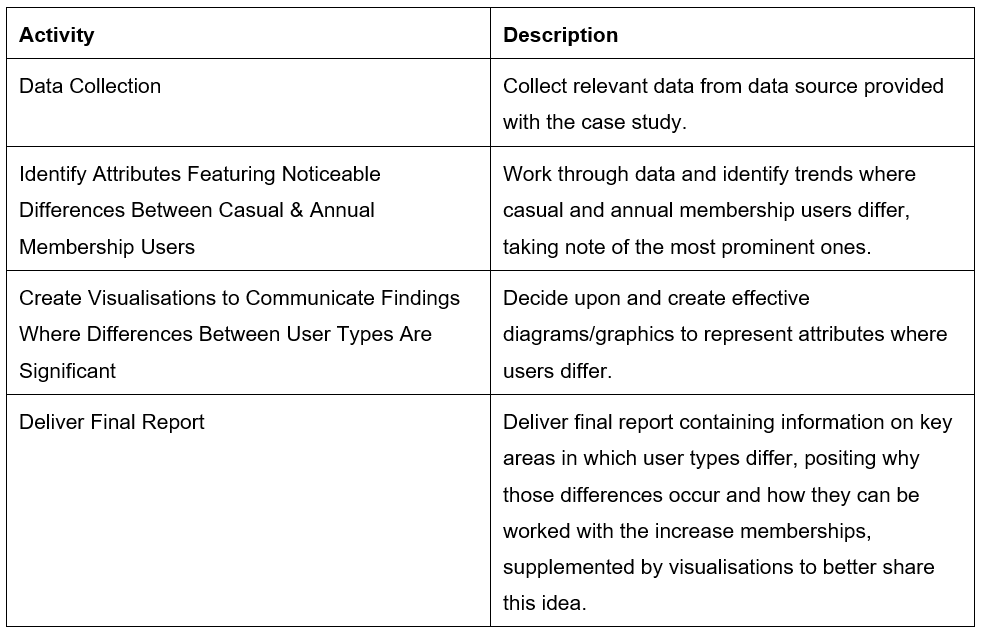

#### This Project Does Not Include:

- Implementation of solutions or recommendations.
- Suggestion of digital media strategies to create more members.
- Consideration of any data that is older than 1 year.

#### Deliverables:

- **Final Report** (*Fulfilled By This Document*)
- **Changelog** (*See Companion Files*)
- **Visualisations of Attributes Where Casual and Annual-Membership Users Differ** (*Fulfilled By This Document*)
- **Recommendations Based Upon the Findings** (*Fulfilled By This Document*)

#### Schedule & Milestones:

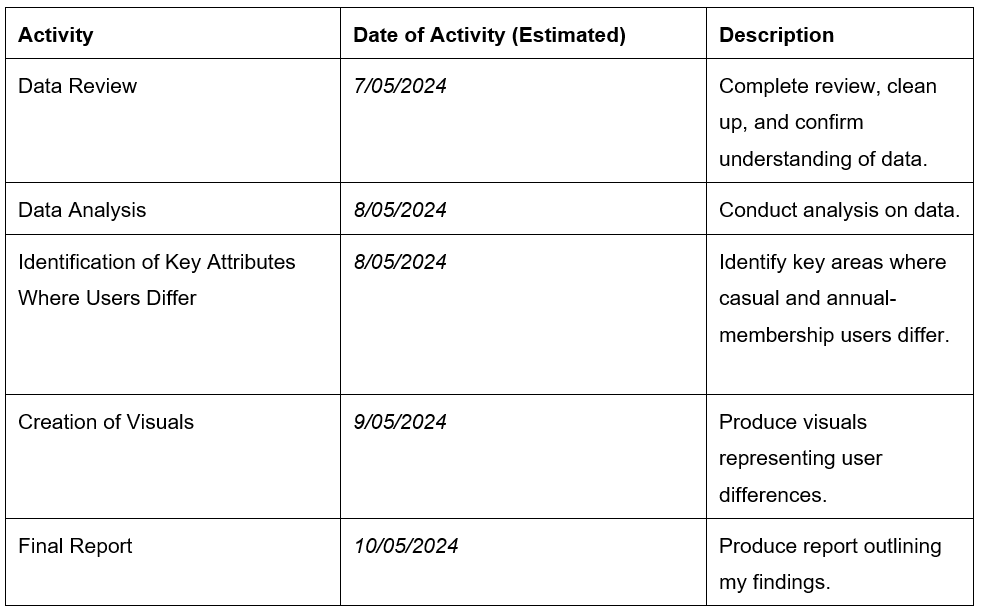

Estimated Date of Completion: **11th of May 2024**

## Data Sources Used

For this case study, data for the analysis was collected from [this link](https://divvy-tripdata.s3.amazonaws.com/index.html) (made available by Motivate International Inc. under [this license](https://divvybikes.com/data-license-agreement), as Cyclistic is a fictional company). The data we will be using is from 2021, categorized by the months of the year at the data source.

To make this information easier to work with, we will be combining the 12 datasets from 2021 into a single dataset comprised of over 5 million records. This involves downloading and extracting each month’s dataset before uploading and combining them via RStudio, where we will also be conducting the cleaning, organisation, and analysis.

Files will also be renamed for ease of use.

E.g. *‘202101-divvy-tripdata’ –> ’01-2021-tripdata’*

## Changelog

The changelog is available as a separate companion file to this report at [this link](https://rohith-vim.github.io/cyclistic-case-study-changelog/)

## Environment Setup

Notes: To begin, we will set up the environment by installing and loading `tidyverse` (comes with `ggplot2`), `janitor`, `lubridate` and `circular`. Ensure these packages are installed before they are loaded.

```r
#load packages
library(tidyverse)
library(janitor)
library(lubridate)
library(ggplot2)
library(circular)
```

## Import Data Files

Notes: Next, we import the Cyclistic data files, which are formatted as CSVs. These files will also be renamed for ease of use during analysis.

*If you are attempting to follow this report’s steps, it’s important that you change the file address depending upon where you’ve stored the case study data.*

```r
#import CSVs

jan21 <- read.csv("C:/Users/remyv/Documents/Cyclistic Case Study/2021_trip_data/01-2021-tripdata.csv")
feb21 <- read.csv("C:/Users/remyv/Documents/Cyclistic Case Study/2021_trip_data/02-2021-tripdata.csv")
mar21 <- read.csv("C:/Users/remyv/Documents/Cyclistic Case Study/2021_trip_data/03-2021-tripdata.csv")
apr21 <- read.csv("C:/Users/remyv/Documents/Cyclistic Case Study/2021_trip_data/04-2021-tripdata.csv")
may21 <- read.csv("C:/Users/remyv/Documents/Cyclistic Case Study/2021_trip_data/05-2021-tripdata.csv")
jun21 <- read.csv("C:/Users/remyv/Documents/Cyclistic Case Study/2021_trip_data/06-2021-tripdata.csv")
jul21 <- read.csv("C:/Users/remyv/Documents/Cyclistic Case Study/2021_trip_data/07-2021-tripdata.csv")
aug21 <- read.csv("C:/Users/remyv/Documents/Cyclistic Case Study/2021_trip_data/08-2021-tripdata.csv")
sep21 <- read.csv("C:/Users/remyv/Documents/Cyclistic Case Study/2021_trip_data/09-2021-tripdata.csv")
oct21 <- read.csv("C:/Users/remyv/Documents/Cyclistic Case Study/2021_trip_data/10-2021-tripdata.csv")
nov21 <- read.csv("C:/Users/remyv/Documents/Cyclistic Case Study/2021_trip_data/11-2021-tripdata.csv")
dec21 <- read.csv("C:/Users/remyv/Documents/Cyclistic Case Study/2021_trip_data/12-2021-tripdata.csv")
```

## Check for Discrepancies

Notes: Before merging the CSVs into a single dataset, we will ensure all data files are identically formatted and that they can be brought together without issues. We will use the `str` function to output the variable names and data types, ensuring these are aligned across all datasets. This is also an opportunity to see if any field has been assigned the wrong data type and to correct this if necessary.

```r
#check datasets for discrepancies

str(jan21)
```

```
## 'data.frame':    96834 obs. of  13 variables:
##  $ ride_id           : chr  "E19E6F1B8D4C42ED" "DC88F20C2C55F27F" "EC45C94683FE3F27" "4FA453A75AE377DB" ...
##  $ rideable_type     : chr  "electric_bike" "electric_bike" "electric_bike" "electric_bike" ...
##  $ started_at        : chr  "2021-01-23 16:14:19" "2021-01-27 18:43:08" "2021-01-21 22:35:54" "2021-01-07 13:31:13" ...
##  $ ended_at          : chr  "2021-01-23 16:24:44" "2021-01-27 18:47:12" "2021-01-21 22:37:14" "2021-01-07 13:42:55" ...
##  $ start_station_name: chr  "California Ave & Cortez St" "California Ave & Cortez St" "California Ave & Cortez St" "California Ave & Cortez St" ...
##  $ start_station_id  : chr  "17660" "17660" "17660" "17660" ...
##  $ end_station_name  : chr  "" "" "" "" ...
##  $ end_station_id    : chr  "" "" "" "" ...
##  $ start_lat         : num  41.9 41.9 41.9 41.9 41.9 ...
##  $ start_lng         : num  -87.7 -87.7 -87.7 -87.7 -87.7 ...
##  $ end_lat           : num  41.9 41.9 41.9 41.9 41.9 ...
##  $ end_lng           : num  -87.7 -87.7 -87.7 -87.7 -87.7 ...
##  $ member_casual     : chr  "member" "member" "member" "member" ...
```

```r
str(feb21)
```

```
## 'data.frame':    49622 obs. of  13 variables:
##  $ ride_id           : chr  "89E7AA6C29227EFF" "0FEFDE2603568365" "E6159D746B2DBB91" "B32D3199F1C2E75B" ...
##  $ rideable_type     : chr  "classic_bike" "classic_bike" "electric_bike" "classic_bike" ...
##  $ started_at        : chr  "2021-02-12 16:14:56" "2021-02-14 17:52:38" "2021-02-09 19:10:18" "2021-02-02 17:49:41" ...
##  $ ended_at          : chr  "2021-02-12 16:21:43" "2021-02-14 18:12:09" "2021-02-09 19:19:10" "2021-02-02 17:54:06" ...
##  $ start_station_name: chr  "Glenwood Ave & Touhy Ave" "Glenwood Ave & Touhy Ave" "Clark St & Lake St" "Wood St & Chicago Ave" ...
##  $ start_station_id  : chr  "525" "525" "KA1503000012" "637" ...
##  $ end_station_name  : chr  "Sheridan Rd & Columbia Ave" "Bosworth Ave & Howard St" "State St & Randolph St" "Honore St & Division St" ...
##  $ end_station_id    : chr  "660" "16806" "TA1305000029" "TA1305000034" ...
##  $ start_lat         : num  42 42 41.9 41.9 41.8 ...
##  $ start_lng         : num  -87.7 -87.7 -87.6 -87.7 -87.6 ...
##  $ end_lat           : num  42 42 41.9 41.9 41.8 ...
##  $ end_lng           : num  -87.7 -87.7 -87.6 -87.7 -87.6 ...
##  $ member_casual     : chr  "member" "casual" "member" "member" ...
```

```r
str(mar21)
```

```
## 'data.frame':    228496 obs. of  13 variables:
##  $ ride_id           : chr  "CFA86D4455AA1030" "30D9DC61227D1AF3" "846D87A15682A284" "994D05AA75A168F2" ...
##  $ rideable_type     : chr  "classic_bike" "classic_bike" "classic_bike" "classic_bike" ...
##  $ started_at        : chr  "2021-03-16 08:32:30" "2021-03-28 01:26:28" "2021-03-11 21:17:29" "2021-03-11 13:26:42" ...
##  $ ended_at          : chr  "2021-03-16 08:36:34" "2021-03-28 01:36:55" "2021-03-11 21:33:53" "2021-03-11 13:55:41" ...
##  $ start_station_name: chr  "Humboldt Blvd & Armitage Ave" "Humboldt Blvd & Armitage Ave" "Shields Ave & 28th Pl" "Winthrop Ave & Lawrence Ave" ...
##  $ start_station_id  : chr  "15651" "15651" "15443" "TA1308000021" ...
##  $ end_station_name  : chr  "Stave St & Armitage Ave" "Central Park Ave & Bloomingdale Ave" "Halsted St & 35th St" "Broadway & Sheridan Rd" ...
##  $ end_station_id    : chr  "13266" "18017" "TA1308000043" "13323" ...
##  $ start_lat         : num  41.9 41.9 41.8 42 42 ...
##  $ start_lng         : num  -87.7 -87.7 -87.6 -87.7 -87.7 ...
##  $ end_lat           : num  41.9 41.9 41.8 42 42.1 ...
##  $ end_lng           : num  -87.7 -87.7 -87.6 -87.6 -87.7 ...
##  $ member_casual     : chr  "casual" "casual" "casual" "casual" ...
```

```r
str(apr21)
```

```
## 'data.frame':    337230 obs. of  13 variables:
##  $ ride_id           : chr  "6C992BD37A98A63F" "1E0145613A209000" "E498E15508A80BAD" "1887262AD101C604" ...
##  $ rideable_type     : chr  "classic_bike" "docked_bike" "docked_bike" "classic_bike" ...
##  $ started_at        : chr  "2021-04-12 18:25:36" "2021-04-27 17:27:11" "2021-04-03 12:42:45" "2021-04-17 09:17:42" ...
##  $ ended_at          : chr  "2021-04-12 18:56:55" "2021-04-27 18:31:29" "2021-04-07 11:40:24" "2021-04-17 09:42:48" ...
##  $ start_station_name: chr  "State St & Pearson St" "Dorchester Ave & 49th St" "Loomis Blvd & 84th St" "Honore St & Division St" ...
##  $ start_station_id  : chr  "TA1307000061" "KA1503000069" "20121" "TA1305000034" ...
##  $ end_station_name  : chr  "Southport Ave & Waveland Ave" "Dorchester Ave & 49th St" "Loomis Blvd & 84th St" "Southport Ave & Waveland Ave" ...
##  $ end_station_id    : chr  "13235" "KA1503000069" "20121" "13235" ...
##  $ start_lat         : num  41.9 41.8 41.7 41.9 41.7 ...
##  $ start_lng         : num  -87.6 -87.6 -87.7 -87.7 -87.7 ...
##  $ end_lat           : num  41.9 41.8 41.7 41.9 41.7 ...
##  $ end_lng           : num  -87.7 -87.6 -87.7 -87.7 -87.7 ...
##  $ member_casual     : chr  "member" "casual" "casual" "member" ...
```

```r
str(may21)
```

```
## 'data.frame':    531633 obs. of  13 variables:
##  $ ride_id           : chr  "C809ED75D6160B2A" "DD59FDCE0ACACAF3" "0AB83CB88C43EFC2" "7881AC6D39110C60" ...
##  $ rideable_type     : chr  "electric_bike" "electric_bike" "electric_bike" "electric_bike" ...
##  $ started_at        : chr  "2021-05-30 11:58:15" "2021-05-30 11:29:14" "2021-05-30 14:24:01" "2021-05-30 14:25:51" ...
##  $ ended_at          : chr  "2021-05-30 12:10:39" "2021-05-30 12:14:09" "2021-05-30 14:25:13" "2021-05-30 14:41:04" ...
##  $ start_station_name: chr  "" "" "" "" ...
##  $ start_station_id  : chr  "" "" "" "" ...
##  $ end_station_name  : chr  "" "" "" "" ...
##  $ end_station_id    : chr  "" "" "" "" ...
##  $ start_lat         : num  41.9 41.9 41.9 41.9 41.9 ...
##  $ start_lng         : num  -87.6 -87.6 -87.7 -87.7 -87.7 ...
##  $ end_lat           : num  41.9 41.8 41.9 41.9 41.9 ...
##  $ end_lng           : num  -87.6 -87.6 -87.7 -87.7 -87.7 ...
##  $ member_casual     : chr  "casual" "casual" "casual" "casual" ...
```

```r
str(jun21)
```

```
## 'data.frame':    729595 obs. of  13 variables:
##  $ ride_id           : chr  "99FEC93BA843FB20" "06048DCFC8520CAF" "9598066F68045DF2" "B03C0FE48C412214" ...
##  $ rideable_type     : chr  "electric_bike" "electric_bike" "electric_bike" "electric_bike" ...
##  $ started_at        : chr  "2021-06-13 14:31:28" "2021-06-04 11:18:02" "2021-06-04 09:49:35" "2021-06-03 19:56:05" ...
##  $ ended_at          : chr  "2021-06-13 14:34:11" "2021-06-04 11:24:19" "2021-06-04 09:55:34" "2021-06-03 20:21:55" ...
##  $ start_station_name: chr  "" "" "" "" ...
##  $ start_station_id  : chr  "" "" "" "" ...
##  $ end_station_name  : chr  "" "" "" "" ...
##  $ end_station_id    : chr  "" "" "" "" ...
##  $ start_lat         : num  41.8 41.8 41.8 41.8 41.8 ...
##  $ start_lng         : num  -87.6 -87.6 -87.6 -87.6 -87.6 ...
##  $ end_lat           : num  41.8 41.8 41.8 41.8 41.8 ...
##  $ end_lng           : num  -87.6 -87.6 -87.6 -87.6 -87.6 ...
##  $ member_casual     : chr  "member" "member" "member" "member" ...
```

```r
str(jul21)
```

```
## 'data.frame':    822410 obs. of  13 variables:
##  $ ride_id           : chr  "0A1B623926EF4E16" "B2D5583A5A5E76EE" "6F264597DDBF427A" "379B58EAB20E8AA5" ...
##  $ rideable_type     : chr  "docked_bike" "classic_bike" "classic_bike" "classic_bike" ...
##  $ started_at        : chr  "2021-07-02 14:44:36" "2021-07-07 16:57:42" "2021-07-25 11:30:55" "2021-07-08 22:08:30" ...
##  $ ended_at          : chr  "2021-07-02 15:19:58" "2021-07-07 17:16:09" "2021-07-25 11:48:45" "2021-07-08 22:23:32" ...
##  $ start_station_name: chr  "Michigan Ave & Washington St" "California Ave & Cortez St" "Wabash Ave & 16th St" "California Ave & Cortez St" ...
##  $ start_station_id  : chr  "13001" "17660" "SL-012" "17660" ...
##  $ end_station_name  : chr  "Halsted St & North Branch St" "Wood St & Hubbard St" "Rush St & Hubbard St" "Carpenter St & Huron St" ...
##  $ end_station_id    : chr  "KA1504000117" "13432" "KA1503000044" "13196" ...
##  $ start_lat         : num  41.9 41.9 41.9 41.9 41.9 ...
##  $ start_lng         : num  -87.6 -87.7 -87.6 -87.7 -87.7 ...
##  $ end_lat           : num  41.9 41.9 41.9 41.9 41.9 ...
##  $ end_lng           : num  -87.6 -87.7 -87.6 -87.7 -87.7 ...
##  $ member_casual     : chr  "casual" "casual" "member" "member" ...
```

```r
str(aug21)
```

```
## 'data.frame':    804352 obs. of  13 variables:
##  $ ride_id           : chr  "99103BB87CC6C1BB" "EAFCCCFB0A3FC5A1" "9EF4F46C57AD234D" "5834D3208BFAF1DA" ...
##  $ rideable_type     : chr  "electric_bike" "electric_bike" "electric_bike" "electric_bike" ...
##  $ started_at        : chr  "2021-08-10 17:15:49" "2021-08-10 17:23:14" "2021-08-21 02:34:23" "2021-08-21 06:52:55" ...
##  $ ended_at          : chr  "2021-08-10 17:22:44" "2021-08-10 17:39:24" "2021-08-21 02:50:36" "2021-08-21 07:08:13" ...
##  $ start_station_name: chr  "" "" "" "" ...
##  $ start_station_id  : chr  "" "" "" "" ...
##  $ end_station_name  : chr  "" "" "" "" ...
##  $ end_station_id    : chr  "" "" "" "" ...
##  $ start_lat         : num  41.8 41.8 42 42 41.8 ...
##  $ start_lng         : num  -87.7 -87.7 -87.7 -87.7 -87.6 ...
##  $ end_lat           : num  41.8 41.8 42 42 41.8 ...
##  $ end_lng           : num  -87.7 -87.6 -87.7 -87.7 -87.6 ...
##  $ member_casual     : chr  "member" "member" "member" "member" ...
```

```r
str(sep21)
```

```
## 'data.frame':    756147 obs. of  13 variables:
##  $ ride_id           : chr  "9DC7B962304CBFD8" "F930E2C6872D6B32" "6EF72137900BB910" "78D1DE133B3DBF55" ...
##  $ rideable_type     : chr  "electric_bike" "electric_bike" "electric_bike" "electric_bike" ...
##  $ started_at        : chr  "2021-09-28 16:07:10" "2021-09-28 14:24:51" "2021-09-28 00:20:16" "2021-09-28 14:51:17" ...
##  $ ended_at          : chr  "2021-09-28 16:09:54" "2021-09-28 14:40:05" "2021-09-28 00:23:57" "2021-09-28 15:00:06" ...
##  $ start_station_name: chr  "" "" "" "" ...
##  $ start_station_id  : chr  "" "" "" "" ...
##  $ end_station_name  : chr  "" "" "" "" ...
##  $ end_station_id    : chr  "" "" "" "" ...
##  $ start_lat         : num  41.9 41.9 41.8 41.8 41.9 ...
##  $ start_lng         : num  -87.7 -87.6 -87.7 -87.7 -87.7 ...
##  $ end_lat           : num  41.9 42 41.8 41.8 41.9 ...
##  $ end_lng           : num  -87.7 -87.7 -87.7 -87.7 -87.7 ...
##  $ member_casual     : chr  "casual" "casual" "casual" "casual" ...
```

```r
str(oct21)
```

```
## 'data.frame':    631226 obs. of  13 variables:
##  $ ride_id           : chr  "620BC6107255BF4C" "4471C70731AB2E45" "26CA69D43D15EE14" "362947F0437E1514" ...
##  $ rideable_type     : chr  "electric_bike" "electric_bike" "electric_bike" "electric_bike" ...
##  $ started_at        : chr  "2021-10-22 12:46:42" "2021-10-21 09:12:37" "2021-10-16 16:28:39" "2021-10-16 16:17:48" ...
##  $ ended_at          : chr  "2021-10-22 12:49:50" "2021-10-21 09:14:14" "2021-10-16 16:36:26" "2021-10-16 16:19:03" ...
##  $ start_station_name: chr  "Kingsbury St & Kinzie St" "" "" "" ...
##  $ start_station_id  : chr  "KA1503000043" "" "" "" ...
##  $ end_station_name  : chr  "" "" "" "" ...
##  $ end_station_id    : chr  "" "" "" "" ...
##  $ start_lat         : num  41.9 41.9 41.9 41.9 41.9 ...
##  $ start_lng         : num  -87.6 -87.7 -87.7 -87.7 -87.7 ...
##  $ end_lat           : num  41.9 41.9 41.9 41.9 41.9 ...
##  $ end_lng           : num  -87.6 -87.7 -87.7 -87.7 -87.7 ...
##  $ member_casual     : chr  "member" "member" "member" "member" ...
```

```r
str(nov21)
```

```
## 'data.frame':    359978 obs. of  13 variables:
##  $ ride_id           : chr  "7C00A93E10556E47" "90854840DFD508BA" "0A7D10CDD144061C" "2F3BE33085BCFF02" ...
##  $ rideable_type     : chr  "electric_bike" "electric_bike" "electric_bike" "electric_bike" ...
##  $ started_at        : chr  "2021-11-27 13:27:38" "2021-11-27 13:38:25" "2021-11-26 22:03:34" "2021-11-27 09:56:49" ...
##  $ ended_at          : chr  "2021-11-27 13:46:38" "2021-11-27 13:56:10" "2021-11-26 22:05:56" "2021-11-27 10:01:50" ...
##  $ start_station_name: chr  "" "" "" "" ...
##  $ start_station_id  : chr  "" "" "" "" ...
##  $ end_station_name  : chr  "" "" "" "" ...
##  $ end_station_id    : chr  "" "" "" "" ...
##  $ start_lat         : num  41.9 42 42 41.9 41.9 ...
##  $ start_lng         : num  -87.7 -87.7 -87.7 -87.8 -87.6 ...
##  $ end_lat           : num  42 41.9 42 41.9 41.9 ...
##  $ end_lng           : num  -87.7 -87.7 -87.7 -87.8 -87.6 ...
##  $ member_casual     : chr  "casual" "casual" "casual" "casual" ...
```

```r
str(dec21)
```

```
## 'data.frame':    247540 obs. of  13 variables:
##  $ ride_id           : chr  "46F8167220E4431F" "73A77762838B32FD" "4CF42452054F59C5" "3278BA87BF698339" ...
##  $ rideable_type     : chr  "electric_bike" "electric_bike" "electric_bike" "classic_bike" ...
##  $ started_at        : chr  "2021-12-07 15:06:07" "2021-12-11 03:43:29" "2021-12-15 23:10:28" "2021-12-26 16:16:10" ...
##  $ ended_at          : chr  "2021-12-07 15:13:42" "2021-12-11 04:10:23" "2021-12-15 23:23:14" "2021-12-26 16:30:53" ...
##  $ start_station_name: chr  "Laflin St & Cullerton St" "LaSalle Dr & Huron St" "Halsted St & North Branch St" "Halsted St & North Branch St" ...
##  $ start_station_id  : chr  "13307" "KP1705001026" "KA1504000117" "KA1504000117" ...
##  $ end_station_name  : chr  "Morgan St & Polk St" "Clarendon Ave & Leland Ave" "Broadway & Barry Ave" "LaSalle Dr & Huron St" ...
##  $ end_station_id    : chr  "TA1307000130" "TA1307000119" "13137" "KP1705001026" ...
##  $ start_lat         : num  41.9 41.9 41.9 41.9 41.9 ...
##  $ start_lng         : num  -87.7 -87.6 -87.6 -87.6 -87.7 ...
##  $ end_lat           : num  41.9 42 41.9 41.9 41.9 ...
##  $ end_lng           : num  -87.7 -87.7 -87.6 -87.6 -87.6 ...
##  $ member_casual     : chr  "member" "casual" "member" "member" ...
```

We notice that the `started_at` and `ended_at` fields are wrongly formatted. These should be *POSIXct*, not *characters*. However, given that we will be merging the datasets shortly, instead of having to convert formats across 12 datasets, we will merge the data before converting these fields.

## Merge Data Files

Notes: Now we can merge the CSV files into a single, new dataset, known as a dataframe in R.

```r
#merges data files into dataframe

dataframe_2021 <- bind_rows(jan21, feb21, mar21, apr21, may21, jun21, jul21, aug21, sep21, oct21, nov21, dec21)
```

## Initial Cleaning of the New Dataset

Notes: With `dataframe_2021` created, it’s time to clean the data and ensure it’s ready for analysis. To start the cleaning process, we will clean field names for consistency using `clean_names()`, remove empty rows/columns using `remove_empty()`, and convert the `started_at` and `ended_at` fields to a `POSIXct` format, which represents calendar time.

```r
#clean and remove spaces and formatting inconsistences

dataframe_2021 <- clean_names(dataframe_2021)

#remove empty rows and columns

dataframe_2021 <- remove_empty(dataframe_2021, which = c())

#convert fields to correct format

dataframe_2021[['started_at']] <- as.POSIXct(dataframe_2021[['started_at']],
                                   format = "%Y-%m-%d %H:%M:%S")

dataframe_2021[['ended_at']] <- as.POSIXct(dataframe_2021[['ended_at']],
                                   format = "%Y-%m-%d %H:%M:%S")
```

## Processing the New Dataset

Notes: Continuing, based on what we can infer from the data, we realise we can extract more value from it if we create a few new columns. Currently, the data is primarily of use at the ‘ride level’; that is, it’s helpful for analysing rider patterns and popular routes.

In order to align the data with the business task and make it more useful for extracting ‘user level’ insights, we can add the following fields.

```r
#add columns for 'start hour', 'day', 'month', 'trip duration' and 'trip distance'

dataframe_2021 <- dataframe_2021 %>%
  mutate(start_hr = hour(started_at)) %>%
  mutate(day = wday(started_at, label = TRUE, abbr = TRUE)) %>%
  mutate(month = month(started_at, label = TRUE, abbr = TRUE)) %>%
  mutate(trip_duration = difftime(ended_at, started_at)) %>%
  mutate(trip_distance = acos(sin(rad(start_lat))*sin(rad(end_lat))+cos(rad(start_lat))
                              *cos(rad(end_lat))*cos(rad(end_lng)-rad(start_lng)))*6371)
```

## Final Cleaning of the New Dataset

Notes: With the data optimised for ‘user level’ analysis, the last step we’ll complete is to remove any trips with a duration of less than 0 seconds. This way, no erroneous records will affect our analysis.

The easiest way to do this would be to create a final, new dataset, and to store the useful records here.

```r
#remove records with 'trip_duration < 0'

dataframe_2021_clean <- dataframe_2021[!(dataframe_2021$trip_duration<=0),]
```

## Visualisation 1 - Number of Rides by Cyclistic Member Type Charted Over A Week

Notes: Using `dataframe_2021_clean`, we can now begin to extract insights from our data. As a reminder, our business task is as follows:

**“How have Cyclistic’s casual and annual-membership users differed in their use of the service over the previous year?”**

With this task in mind, let’s start with a chart comparing the total number of rides by casual users and members in 2021 charted over the course of a week.

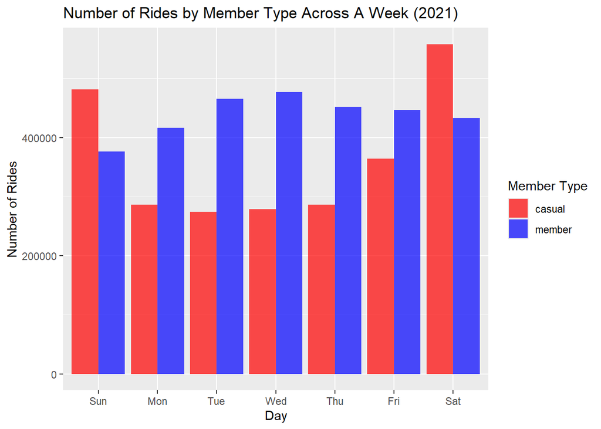

```r
#`scipen` used to output `Number of Rides` in a non-exponential format

options(scipen = 100, digits = 4)

#creates a bar chart showing number of rides by cyclistic member type charted over a week

ggplot(dataframe_2021_clean, aes(x=day, fill=member_casual)) +
  geom_bar(position="dodge", alpha=0.7) +
  labs(title="Number of Rides by Member Type Across A Week (2021)",
       x="Day",
       y="Number of Rides",
       fill="Member Type") +
  scale_fill_manual(values=c("red",
                             "blue"))
```

Observations:

**We find that members account for more rides on weekdays**, whereas, **on weekends, we see an uptick in casual user rides**.

This might be due to members using Cyclistic as a primary method of transportation between residences and workplaces/schools, whereas casual users are more likely to engage with Cyclistic for entertainment/recreational use. For such users, a membership may seem excessive, as they would only make use of Cyclistic on weekends.

However, this isn’t enough to make a concrete assumption on. To find out more, let’s analyse more fields.

## Visualisation 2 - Number of Rides by Cyclistic Member Type Charted Across the Months of the Year

Notes: Next, lets compare the total number of rides by casual users and members in 2021 charted across the months of the year.

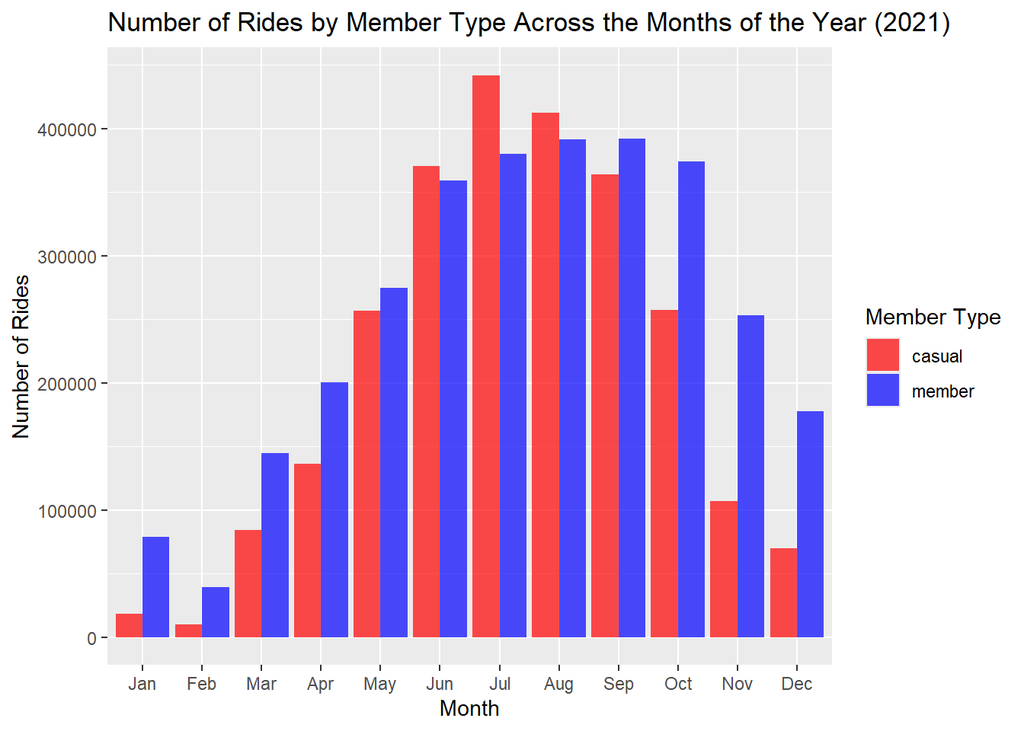

```r
#`scipen` used to output `Number of Rides` in a non-exponential format

options(scipen = 100, digits = 4)

#creates a bar chart showing the number of rides by cyclistic member type charted across the months of the year

ggplot(dataframe_2021_clean, aes(x=month, fill=member_casual)) +
  geom_bar(position="dodge", alpha=0.7) +
  labs(title="Number of Rides by Member Type Across the Months of the Year (2021)",
       x="Month",
       y="Number of Rides",
       fill="Member Type") +
  scale_fill_manual(values=c("red",
                             "blue"))
```

Observations:

It appears as though **members account for more trips in all months bar the summer ones of June, July and August, when casual users overtake them**. Following on with our theory of entertainment and recreational use, casual users seem more inclined to engage with Cyclistic when they have holidays. It’s worth noting that June, July and August coincide with summer vacation time for many schools, and families may take holidays to enjoy the good weather and to cycle around the city. We will attempt to reinforce this notion in a later visualisation.

On the topic of seasons, we also see that more trips are taken in the summer months than in the winter ones. Given that Cyclistic is based in Chicago, this is likely explained by temperature differences, where summer months are milder and winter ones more extreme.

## Visualisation 3 - Hourly Use of Bikes by Member Type Across A Week

Notes: To learn more about the times at which Cyclistic bikes were used in 2021, the next visual will chart hourly bike usage by members and casual users over a week.

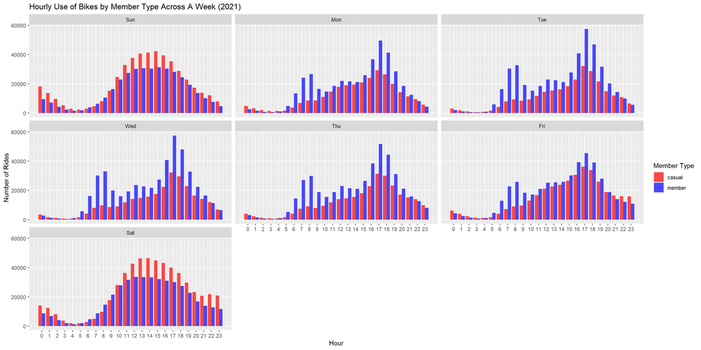

```r
#`scipen` used to output `Number of Rides` in a non-exponential format

options(scipen = 100, digits = 4)

#creates a bar chart showing the hourly use of bikes by member type across a week

ggplot(dataframe_2021_clean, aes(x=start_hr, fill=member_casual)) +
  geom_bar(position="dodge", alpha=0.7) +
  scale_x_continuous(breaks=seq(00,23,1)) +
  facet_wrap(~day) +
  labs(title="Hourly Use of Bikes by Member Type Across A Week (2021)",
       x="Hour",
       y="Number of Rides",
       fill="Member Type") +
  scale_fill_manual(values=c("red",
                             "blue"))
```

Observations:

Thus far, the data seems to suggest that casual users engage with Cyclistic in their free time and for leisure, whereas members use Cyclistic bikes as a primary method of transporation.

## Visualisation 4 - Average Trip Duration Between Casual and Annual Membership Users

Notes: Another useful visualisation would be to map the difference in average trip duration between Cyclistic user types.

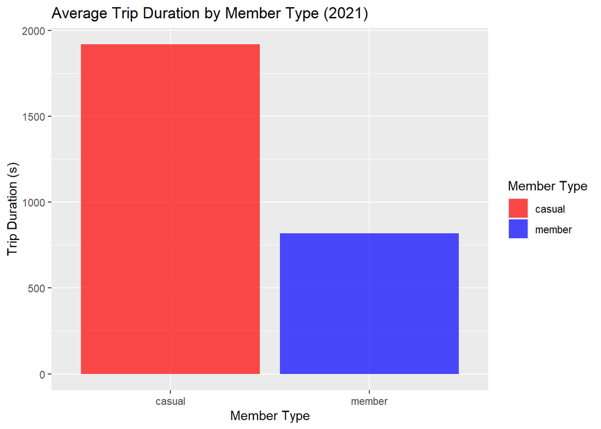

```r
#`scipen` used to output `Number of Rides` in a non-exponential format

options(scipen = 100, digits = 4)

#creates a bar chart showing the average trip duration for casual and annual membership users

ggplot(dataframe_2021_clean, aes(x = member_casual, y = trip_duration, fill=member_casual)) +
  geom_bar(position="dodge",
           alpha=0.7,
           stat="summary",
           fun="mean") +
  labs(title="Average Trip Duration by Member Type (2021)",
       x="Member Type",
       y="Trip Duration (s)",
       fill="Member Type") +
  scale_fill_manual(values=c("red",
                             "blue"))
```

Observations:

It may also be a question of value. For casual users, who likely pay a one-time fee to take a single trip, they would want to maximise their use of the bike, whereas members, who may pay a flat fee for unlimited trips, are less likely to be concerned about maximising their trip duration.

## Visualisation 5 - Average Trip Distance Between Casual and Annual Membership Users

Notes: Following the previous graphic, lets also look compare the average trip distance between Cyclistic user types.

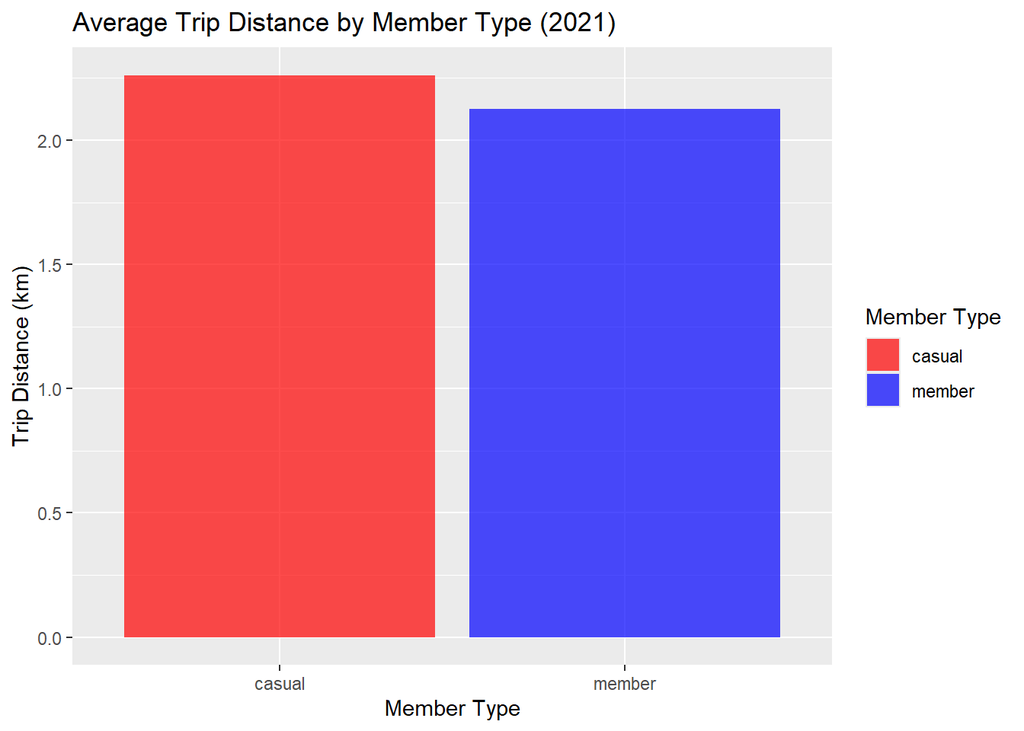

```r
#`scipen` used to output `Number of Rides` in a non-exponential format

options(scipen = 100, digits = 4)

#creates a bar chart showing the average trip distance for casual and annual membership users

ggplot(dataframe_2021_clean, aes(x = member_casual, y = trip_distance, fill=member_casual)) +
  geom_bar(position="dodge",
           alpha=0.7,
           stat="summary",
           fun="mean") +
  labs(title="Average Trip Distance by Member Type (2021)",
       x="Member Type",
       y="Trip Distance (km)",
       fill="Member Type") +
  scale_fill_manual(values=c("red",
                             "blue"))
```

Observations:

**Interestingly, casual users and members appear to take trips that cover close to the same distance**. Though alone this data doesn’t offer much in the way of insight, we can combine our findings from the previous visualisation to reinforce our existing propositions. Since it appears that members complete journeys of a similar length to casual users in less time, they may do so with the intent of reaching a destination by a deadline. Casual users, perhaps using Cyclistic bikes in their free time, are in no particular hurry to meet or follow a schedule. Hence, they complete their trips at a leisurely pace.

All in all, our graphed findings have lent a great deal of support to the theory of casual/member use of Cyclistic services which has been explored throughout these sections.

To continue, lets take another approach with the data.

## Visualisation 6 - Mapping the Most Popular Start & End Stations for Casual Users

Notes: The remaining visualisations will be mapped. To facilitate this, we will export data on the 10 most commonly used start and end stations by Cyclistic casual users, which we can comebine into a single dataset via Excel before visualising with Tableau.

*If you would like to view the viz with additional information including specific trip count and ranking details, visit [this link](https://public.tableau.com/views/CyclisticCaseStudy-CasualUsersBook/Dashboard1?:language=en-GB&:sid=&:display_count=n&:origin=viz_share_link)*

```r
## Create Subset of Dataframe with A Count for Start Station Usage By Casual Users

top_start_stations_users <- dataframe_2021_clean %>%
  filter(member_casual=="casual") %>%
  count(start_station_name, sort = TRUE)

## Remove Top Value (Which is Empty) and Keep Only the Top 10 Start Stations and Their Trip Count

top_start_stations_users <- head(top_start_stations_users, 11)
top_start_stations_users <- top_start_stations_users[-1,]
rownames(top_start_stations_users) <- NULL

## Declare Vectors for Start Station Latitude and Longitude, Which We Need for the Export

top_user_start_streets_lat <- c(41.89228, 41.88103, 41.90096, 41.86723, 41.92628,
                                41.91213, 41.88096, 41.91569, 41.90322, 41.86789)

top_user_start_streets_long <- c(-87.61204, -87.62408, -87.62378, -87.61536, -87.63083,
                                 -87.63466, -87.61674, -87.63460, -87.63432, -87.62304)

## Add Vectors for Start Station Latitude and Longitude to the Subset of Top 10 Start Stations

top_start_stations_users$start_lat <- top_user_start_streets_lat

top_start_stations_users$start_long <- top_user_start_streets_long

## Create CSV File to Export

write.csv(top_start_stations_users, "casual_start_stations.csv")

## Create Subset of Dataframe with A Count for End Station Usage By Casual Users

top_end_stations_users <- dataframe_2021_clean %>%
  filter(member_casual=="casual") %>%
  count(end_station_name, sort = TRUE)

## Remove Top Value (Which is Empty) and Keep Only the Top 10 End Stations and Their Trip Count

top_end_stations_users <- head(top_end_stations_users, 11)
top_end_stations_users <- top_end_stations_users[-1,]
rownames(top_end_stations_users) <- NULL

## Declare Vectors for End Station Latitude and Longitude, Which We Need for the Export

top_user_end_streets_lat <- c(41.89228, 41.88103, 41.90096, 41.92628, 41.86723,
                                41.91213, 41.88096, 41.91172, 41.91569, 41.89147)

top_user_end_streets_long <- c(-87.61204, -87.62408, -87.62378, -87.63083, -87.61536,
                                 -87.63466, -87.61674, -87.62680, -87.63460, -87.62676)

## Add Vectors for End Station Latitude and Longitude to the Subset of Top 10 End Stations

top_end_stations_users$end_lat <- top_user_end_streets_lat

top_end_stations_users$end_long <- top_user_end_streets_long

## Create CSV File to Export

write.csv(top_end_stations_users, "casual_end_stations.csv")
```

[figure not shown]

*Output Once Processed In Tableau*

Observations:

**Casual users most commonly make use of Cyclistic’s services in prominent tourist/lesiure areas within Chicago**. Looking at the map, we see trips starting across the shorefront, and between destinations such as ‘Shedd Aquarium’, ‘Theater on the Lake’, and around ‘Lincoln Park Zoo’. We see a reasonable variety between start and stop stations, indicating that users aren’t bound to a particular path/destination in their trips.

## Visualisation 7 - Mapping the Most Popular Start & End Stations for Annual Members

Notes: Now we will export data on the 10 most commonly used start and end stations by Cyclistic annual members, which we will also combine via Excel represent with Tableau.

*If you would like to view the viz with additional information including specific trip count and ranking details, visit [this link](https://public.tableau.com/views/CyclisticCaseStudy-AnnualMembersBook/Dashboard1?:language=en-GB&:sid=&:display_count=n&:origin=viz_share_link)*

```r
## Create Subset of Dataframe with A Count for Start Station Usage By Annual Members

top_start_stations_members <- dataframe_2021_clean %>%
  filter(member_casual=="member") %>%
  count(start_station_name, sort = TRUE)

## Remove Top Value (Which is Empty) and Keep Only the Top 10 Start Stations and Their Trip Count

top_start_stations_members <- head(top_start_stations_members, 11)
top_start_stations_members <- top_start_stations_members[-1,]
rownames(top_start_stations_members) <- NULL

## Declare Vectors for Start Station Latitude and Longitude, Which We Need for the Export

top_member_start_streets_lat <- c(41.90297, 41.91213, 41.88918, 41.90322, 41.89399,
                               41.89472, 41.89435, 41.93758, 41.88224, 41.88872)

top_member_start_streets_long <- c(-87.63128, -87.63466, -87.63851, -87.63432, -87.62932,
                                -87.63436, -87.62280, -87.64410, -87.64107, -87.64445)

## Add Vectors for Start Station Latitude and Longitude to the Subset of Top 10 Start Stations

top_start_stations_members$start_lat <- top_member_start_streets_lat

top_start_stations_members$start_long <- top_member_start_streets_long

## Create CSV File to Export

write.csv(top_start_stations_members, "members_start_stations.csv")

## Create Subset of Dataframe with A Count for End Station Usage By Annual Members

top_end_stations_members <- dataframe_2021_clean %>%
  filter(member_casual=="member") %>%
  count(end_station_name, sort = TRUE)

## Remove Top Value (Which is Empty) and Keep Only the Top 10 End Stations and Their Trip Count

top_end_stations_members <- head(top_end_stations_members, 11)
top_end_stations_members <- top_end_stations_members[-1,]
rownames(top_end_stations_members) <- NULL

## Declare Vectors for End Station Latitude and Longitude, Which We Need for the Export

top_member_end_streets_lat <- c(41.90297, 41.91213, 41.88918, 41.90322, 41.89399,
                               41.89435, 41.89472, 41.93758, 41.88224, 41.88189)

top_member_end_streets_long <- c(-87.63128, -87.63466, -87.63851, -87.63432, -87.62932,
                                -87.62280, -87.63436, -87.64410, -87.64107, -87.64879)

## Add Vectors for End Station Latitude and Longitude to the Subset of Top 10 End Stations

top_end_stations_members$end_lat <- top_member_end_streets_lat

top_end_stations_members$end_long <- top_member_end_streets_long

## Create CSV File to Export

write.csv(top_end_stations_members, "members_end_stations.csv")
```

[figure not shown]

*Output Once Processed In Tableau*

Observations:

**Member trips seem to start and stop at almost the exact same stations**. As a matter of fact, only one of the 10 most popular stations to start from varies from the 10 most popular stations to stop at. We also see that many stops occur in the downtown region, where businesses, schools, and universities likely operate. None of the prominent member stops exist in leisure areas either. All of this suggests that members follow defined, pre-considered paths from what are likely areas of residence/metro stations to areas of work/study. The consistency between start and stop stations suggests members have places to be at particular times; they aren’t using Cyclistic with the same intent as casual users.

## Recommendations

Given these findings, there are a number of actions we can take to potentially increase the number of members using Cyclistic.

#### Advertising:

- **Increase advertisements shown around the most popular start/end stations for casual users**. To increase the effectiveness of these ads, run them over weekends, when more riders are likely to see them.

#### Membership Adjustments:

- **Provide more membership options**. For example, with an uptick in members over the summer months, a seasonal membership might be of interest to casual users during this time. This can also be offered over spring/autumn months to increase engagement with Cyclistic over these time periods.
- **Offer discounts for membership over the winter months to encourage more casual users to convert**. This may also encourage more use of Cyclistic bikes in the winter months.
- **Introduce a ‘Recommend A Friend’ programme, wherein a paying member can recommend a casual-user friend, who may receive a discount when they register for Cyclistic’s membership**. The paying member may also be offered a discount if they recommend a friend, should they want to renew their membership.
- **Provide more value with the membership**. For example, if the Cyclistic app were to integrate a feature showing members the best route to take between stations, it might encourage more users to invest.

To conclude, by taking the right steps taken and executing the proper actions, Cyclistic can greatly increase the number of casual users it converts into members.